# Lab1_Hee

## Q1. Line graph and reading the graph

Please use the "bitcoin.csv" file to see the data. In this dataset, you can see Bitcoin prices from the start of 2014 to the start of 2022.

Look at the Bitcoin prices for each year. Which year began with the highest? Visualize the bitcoin prices over the years.

Tip: There is more than one right answer. Please use your imagination to visualize the most impactful plot.

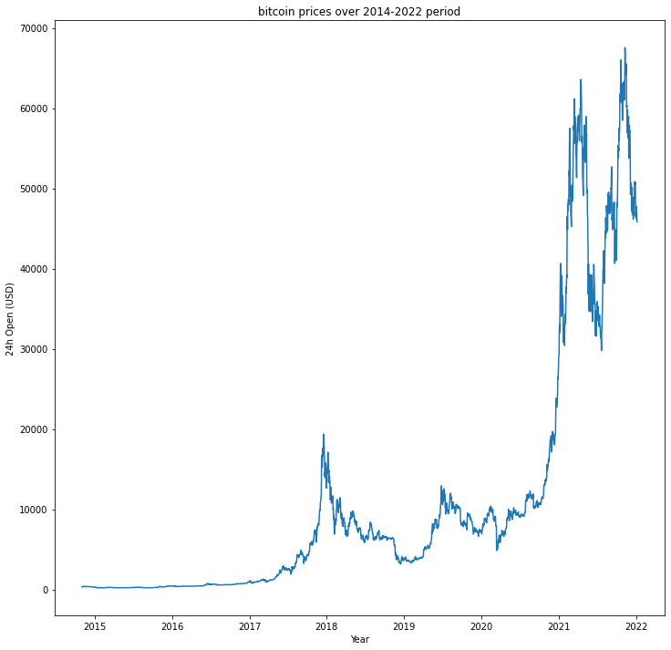

```python
import pandas as pd
import matplotlib.pyplot as plt
from matplotlib.pyplot import figure
from matplotlib.dates import DateFormatter

file = pd.read_csv("bitcoin.csv")
df = pd.DataFrame(file)
# print(df.columns)
df = df[["Date", "24h Open (USD)"]]
x = df["Date"].apply(pd.to_datetime)
y = df["24h Open (USD)"]

# Create figure and plot space
fig, ax = plt.subplots(figsize=(12, 12))

# Add x-axis and y-axis
ax.plot(x,y)

# Set title and labels for axes
ax.set(xlabel="Year",
       ylabel="24h Open (USD)",
       title="bitcoin prices over 2014-2022 period")

# Display only the Year from date
date_form = DateFormatter("%Y")
ax.xaxis.set_major_formatter(date_form)
plt.show()

#As shown on the graph, 2022 begins with the highest price.
```

## Q2. Interpreting histograms

Here is a dataset of salaries ("salary.csv") for various jobs in Australia.

Each row of the dataset represents the average salary for that job (for each gender), so the counts are counts of jobs. Visualize the salaries with using histogram and answer following questions;

1. Is the histogram bimodal or unimodal?
2. Is the histogram right-skewed or left skewed?
3. What is the most popular (frequent) salary bracket?
4. Investigate whether there is an equal pay for men and women

Change the bin-size and observe how the histogram changes.

Which bin size selection seems best for you?

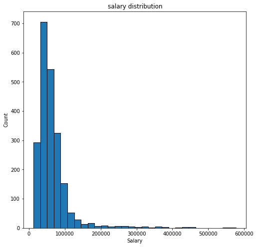

```python
file = pd.read_csv("salary.csv", encoding="ISO-8859-1")
df = pd.DataFrame(file)
plt.figure(figsize=(8,8))
plt.hist(df['average_taxable_income'], bins = 30, edgecolor = 'black')
plt.xlabel('Salary')
plt.ylabel('Count')
plt.title("salary distribution")
plt.show()
```

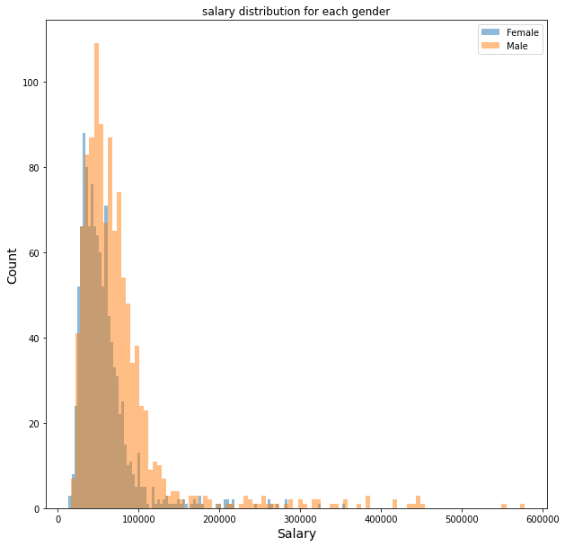

```python
df_w = df[df['gender'] == "Female"]
df_m = df[df['gender'] == "Male"]
plt.figure(figsize=(10,10))
plt.hist(df_w['average_taxable_income'], bins=100, alpha=0.5, label="Female")
plt.hist(df_m['average_taxable_income'], bins=100, alpha=0.5, label="Male")
plt.xlabel("Salary", size=14)
plt.ylabel("Count", size=14)
plt.title("salary distribution for each gender")
plt.legend(loc='upper right')
```

## Q3. Box plots

Please follow the Google Drive link to open the box plot of cigarette consumption per person in the USA from 1985 to 1995 (Alaska and Hawaii are not included).

Each observation in the dataset is the average number of packets of cigarette smoked per person in one state in one year.

Thus each box plot represents the distribution of 48 data points (because there are 48 US states included in the dataset).

[figure not shown]

See the the box plot: https://drive.google.com/file/d/1TJVpPUiM2Q1RQbcg6L9r-PXc1HFWY7hk/view?usp=sharing

Please see the explanaitions of the features from the following link;

https://www.rdocumentation.org/packages/Ecdat/versions/0.3-9/topics/Cigarette

# Q3. (a)

From the above box plot answer the following questions as **True** or **False**;

1. The upper quartile number of packets of ciagrettes smoked per capita decrased every year from 1985 to 1995.
2. The median number of packets of cigarettes smoked per capita was below 100 from 1991 onwards.
3. The interquartile range of the number of packets of cigarettes smoked per capita was smallest 1992.
4. In 1990, three states were considered to have extreme values in the number of packets of cigarettes smoked per capita.
5. The interquartile range of the number of packets of cigarettes smoked per capita decreased every year from 1985 to 1995.
6. The lower quartile number of packets of cigarettes smoked per capita decreased every year from 1985 to 1995.

Q3. (a) Answers

1. F
2. T
3. F
4. T
5. F
6. T

# Q3. (b)

Use the "cigarette.csv" and seaborn library to plot following box plots;

1. year vs package per capita (packpc)
2. state vs package per capita (packpc) -- order the box plots by state names and by median of the packpc

From the state vs package box plots which statement is False?

a. The lower whisker for Alabama is completely above 100 packs/capita/year.

b. North Carolina (NC) has the fourth highest median consumption.

c. Idaho (ID) has the fourth lowest median consumption.

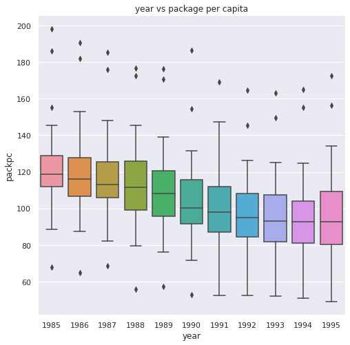

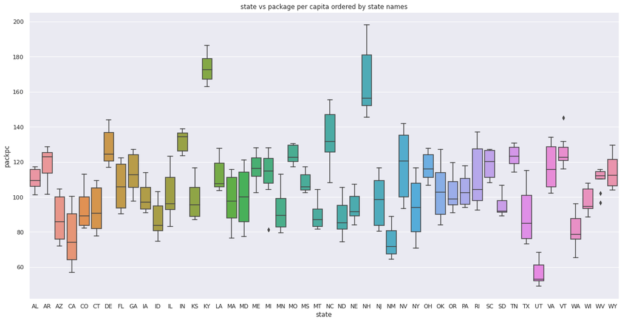

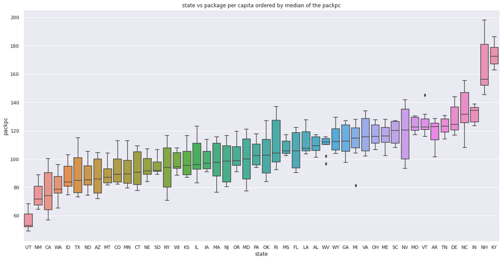

```python
import seaborn as sns
import matplotlib.pyplot as plt

file = pd.read_csv("cigarette.csv")
df = pd.DataFrame(file)

plt.figure(figsize=(8,8))
sns.boxplot(x=df["year"], y=df["packpc"])
plt.title("year vs package per capita")
plt.show()
print()
plt.figure(figsize=(20,10))
plt.title("state vs package per capita ordered by state names")
sns.boxplot(x=df["state"], y=df["packpc"])
plt.show()
print()
df = df[['state', 'packpc']]
order = df.groupby("state")["packpc"].median().sort_values()[::].index
plt.figure(figsize=(20,10))
plt.title("state vs package per capita ordered by median of the packpc")
sns.boxplot(x='state', y='packpc', data=df, order=order)
plt.show()
```

From the state vs package box plots which statement is False?

### C is false

a. The lower whisker for Alabama is completely above 100 packs/capita/year. True

b. North Carolina (NC) has the fourth highest median consumption. True

c. Idaho (ID) has the fourth lowest median consumption. False